# Darren Hunt

PHYS 434AA

12/13/2020

Labs 7 & 8

```python
%matplotlib inline
import numpy as np
import matplotlib
import matplotlib.pyplot as plt
from scipy import stats
import scipy
import pickle
import pandas as pd
plt.style.use('ggplot')
```

# Part 1: Event Selection Optimization

```python
# import signal and background data. using low transverse momentum datasets (250-500)
higgs = open("higgs1.pkl",'rb')
qcd = open("qcd1.pkl", 'rb')  # background data
higgs_dict = pickle.load(higgs)
qcd_dict = pickle.load(qcd)
```

```python
# import data: two datasets, one high luminosity, one low. both are for the low pt sample set used above.
# this will be used in part 2 of the lab.
highlum = pd.read_hdf('highlum.h5')
lowlum = pd.read_hdf('lowlum.h5')
```

```python
# function to plot histograms to examine data, also plots a log view of histogram
def hist_plotter(param,bg,label):
    bins = 100

    fig, (ax1, ax2) = plt.subplots(1, 2, figsize=(18,8), gridspec_kw={'wspace': 0.4})
    plt.style.use('ggplot')
    ax1.set_title(label+" Histogram", fontsize=22)
    ax2.set_title("Log "+label+" Histogram", fontsize=22)
    ax1.set_xlabel(label, fontsize=20), ax2.set_xlabel(label, fontsize=20)
    ax1.set_ylabel("Probability", fontsize=20), ax2.set_ylabel("Log Probability", fontsize=20)
    ax1.tick_params(labelsize=18), ax2.tick_params(labelsize=18)

    ax1.hist(param,bins=bins,density=True,color='r',alpha=0.7,label="Signal")
    ax1.hist(bg,bins=bins,density=True,color='b',alpha=0.6,label="Background")

    ax2.hist(param,bins=bins,density=True,color='r',alpha=0.7,label="Signal")
    ax2.hist(bg,bins=bins,density=True,color='b',alpha=0.6,label="Background")
    ax2.set_yscale('log')

    ax1.legend(loc='best',fontsize=16)
    ax2.legend(loc='best',fontsize=16)
    plt.show()
```

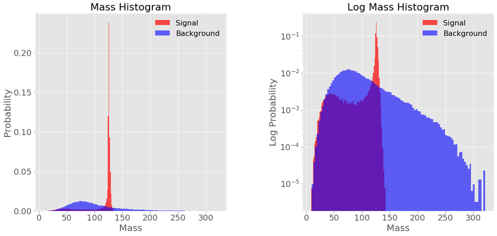

```python
mass = higgs_dict['mass']
bgmass = qcd_dict['mass']
hist_plotter(mass,bgmass,'Mass')
```

To begin working with any large dataset, we can start with basic histograms of relevant parameters to get a general idea of data and background distribution shapes and what range of values are observed. Above we have plotted in red the shape of the signal, where much of the signal is located under the peak at about a mass of 125. The mean is about 115 (found in the next cell), and is slightly below this peak. The background is much flatter and wide in comparison, centered at about a mass of 75 and has a mean of 97.

It is always useful to examine a semilog plot of the histogram as well, where we can see minor changes in the signal and background much more clearly.

```python
n = 100
nqcd = 20000

mumass = np.mean(mass)
mubgmass = np.mean(bgmass)
h = np.median(mass)  # Higgs mass, the peak of the histogram

print("Higgs Boson mass : "+str("{0:.2f}".format(h)))
print("Signal mean : "+str("{0:.2f}".format(mumass)))  # from the histogram, before normalizing
print("Background mean : "+str("{0:.2f}".format(mubgmass)))  # ditto
```

```
Higgs Boson mass : 125.29
Signal mean : 114.89
Background mean : 97.74
```

## Statistical significances without event selection

First, we calculate the expected significance of a signal observation for the whole dataset, without making any cuts to the data. We can use a Poisson distribution to perform this calculation. A Poisson is an appropriate distribution choice for these statistics. The nature of the Higgs events is discrete, and the corresponding Poisson's shape will take after the mean of the dataset.

```python
# calculate expected significance without event selection
uncut = stats.poisson.cdf(h,mubgmass)
print("Sigma value (without event selection) : "+str("{0:.3f}".format(uncut)))
```

```
Sigma value (without event selection) : 0.997
```

The Poisson shape is determined by the mean of the background. Since we are looking for statistically significant events that might occur, we must look at the background, which can tell us whether or not something we observe is a discovery or just expected noise.

This calculation yielded $\sigma = 0.997$. Without optimizing the data, this is very far from a statistically significant, which is generally accepted to be $5\sigma$.

```python
# comparing NHiggs and NQCD numbers
sqrtnqcd = np.sqrt(nqcd)
r = n / sqrtnqcd

print("N Higgs : "+str("{0:.2f}".format(n)))
print("Sqrt N QCD : "+str("{0:.2f}".format(sqrtnqcd)))
print("Ratio comparison : "+str("{0:.2f}".format(r)))
```

```
N Higgs : 100.00
Sqrt N QCD : 141.42
Ratio comparison : 0.71
```

Before making any data cuts in the low transverse momentum set, the $N_{Higgs}$ expected events is known to be 100, and $N_{QCD}$ is expected to be 20,000. This means that in a large dataset searching for a Higgs event, we expect 100 to be true significant observations, and 20,000 to be attributable to the background. Comparing these given $N_{Higgs} / \sqrt {N_{QCD}}$ values, we see than the QCD has a larger number and contribution. Taking the ratio gives 0.71, indicating that the background is contributing much more than Higgs events.

## Cutting the mass parameter to optimize expected significance

We can optimize the expected significance by slicing the mass data to focus on the most relevant and frequently occurring signal data, while minimizing how much background impacts our calculation. The initially plotted histograms give a general idea of the shape of the background, and where most of the signal values are located (the most probable part of the curve above).

```python
# function to cut an input parameter, cuts and returns both signal and background datasets
# pulls any data point where a signal or background value falls within specified range
def data_slicer(param,start,stop,obs):
    sliced = list(filter(lambda l: l >= start and l < stop, higgs_dict[param]))
    slicedbg = list(filter(lambda l: l >= start and l < stop, qcd_dict[param]))
    if obs == True:
        cutHighLum = list(filter(lambda l: l >= start and l < stop, highlum[param]))
        cutLowLum = list(filter(lambda l: l >= start and l < stop, lowlum[param]))
        return sliced, slicedbg, cutHighLum, cutLowLum
    else:
        return sliced, slicedbg
```

```python
# a function to calculate the sigma value using Poisson statistics
# must use the background data for param
# normalizes to NQCD = 20000 and NHiggs=100
def sigma(cut,param):
    # first normalize
    n, nqcd = 100, 20000
    norm = (sum(cut[0]) / sum(higgs_dict[param])) * n
    normbg = (sum(cut[1]) / sum(qcd_dict[param])) * nqcd

    r = np.abs(norm / np.sqrt(normbg))  # ratio
    print("Expected Sigma : " + str("{0:.4f}".format(r)))
```

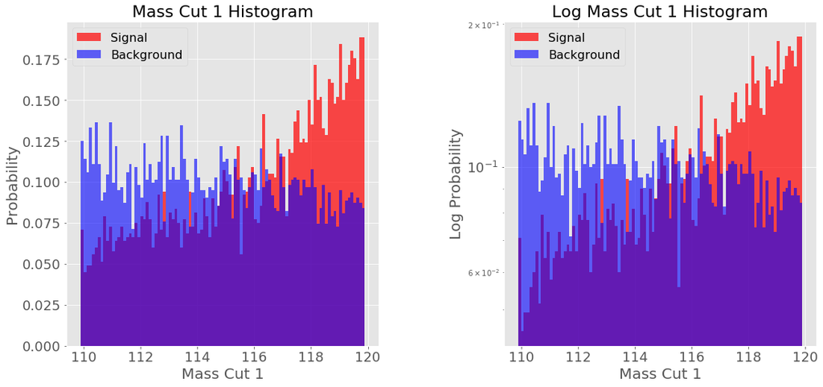

```
Expected Sigma : 0.1223
```

```python
# initial cut, rough estimate to get started
c0 = data_slicer('mass',mumass-5,mumass+5,False)

# plot the sliced data as a +histogram
hist_plotter(c0[0],c0[1],'Mass Cut 1')

# sigma value
sigma(c0,'mass')
```

This initial mass cut, which took values 5 below the mean and 5 above the mean, does not optimize the mass parameter, as the expected sigma is near 0. The significance has decreased below the pre-cut sigma value, likely due to cutting too much of the signal data out. While we want to reduce the background's presence, eliminating too much of the expected signal data does more harm than good.

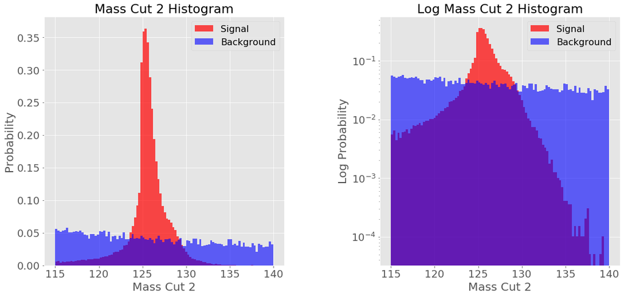

```
Expected Sigma : 1.6084
```

```python
c1 = data_slicer('mass',115,140,False)
hist_plotter(c1[0],c1[1],'Mass Cut 2')
sigma(c1,'mass')
```

This cut, with a very rough estimate made by looking at the initial histogram of the mass parameter, is closer to optimizing the expected significance. Now, we are above the expectde significance for the pre-cut mass data. This graph gives us a little closer look at where to try cutting for our next attempt.

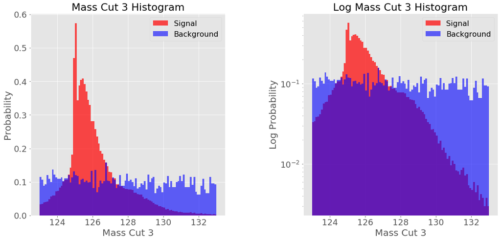

```
Expected Sigma : 2.3457
```

```python
c2 = data_slicer('mass',123,133,False)
hist_plotter(c2[0],c2[1],'Mass Cut 3')
sigma(c2,'mass')
```

The expected significance for the mass parameter is now above $2\sigma$, so the mass cuts are approaching a more optimized set of data.

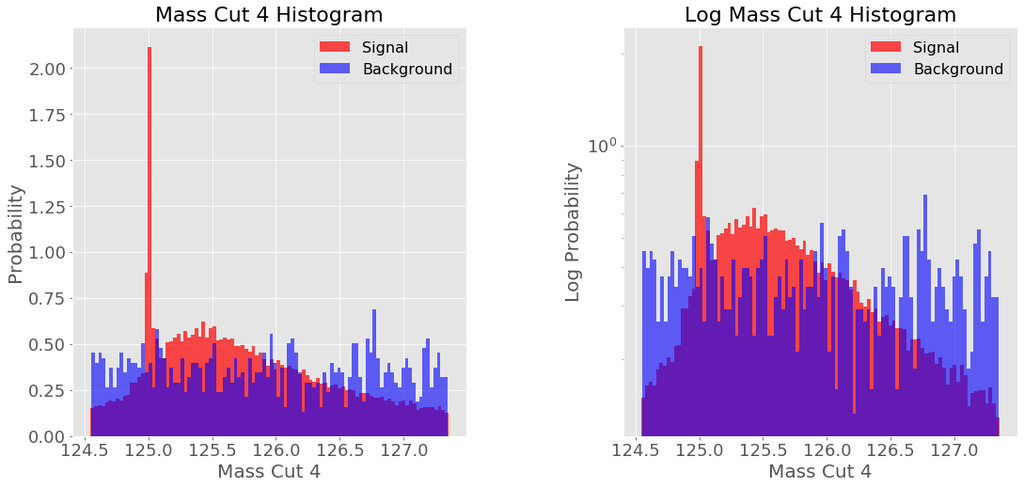

```
Expected Sigma : 3.0868
```

```python
c3 = data_slicer('mass',124.55,127.35,False)
hist_plotter(c3[0],c3[1],'Mass Cut 4')
sigma(c3,'mass')
```

After fine-tuning the lower and upper bounds for slicing the mass dataset, this final mass cut between a value of 124.55 and 127.35 yields the highest significance, with $\sigma=3.087$. Adjusting the data cut to more precise values increased the expected significance by over two sigma from the original mass dataset.

# Examining All Parameters Before Data Optimization

The Higgs dataset includes several other parameters for exploration: transverse momentum, $\eta$ angle, $\phi$ angle, mass (which we have already examined), the second and third ECFs and the ratio of the two, angularity, 1,2,3 subjettiness, 2-1 and 3-2 subjettiness ratios, and $k_t \Delta R$.

```python
higgs_dict.keys()
```

```
Index(['pt', 'eta', 'phi', 'mass', 'ee2', 'ee3', 'd2', 'angularity', 't1',
       't2', 't3', 't21', 't32', 'KtDeltaR'],
      dtype='object')
```

To begin, we will view each of these parameters before making any cuts to the datasets. I plotted these quickly using a loop over the keys (without the mass parameter included) and plugging each key into the hist_plotter function written earlier.

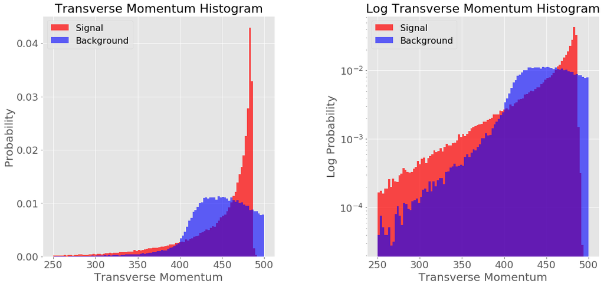

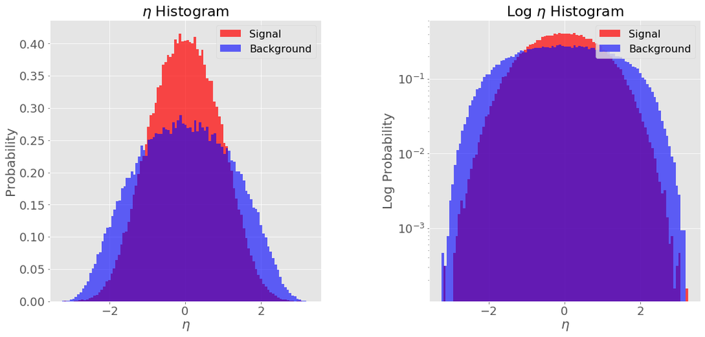

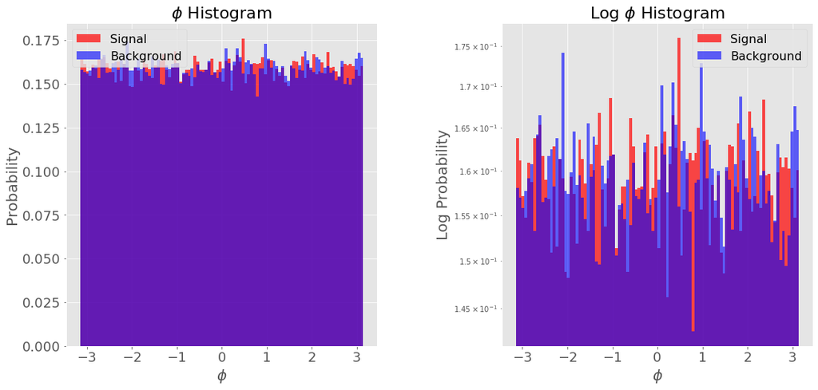

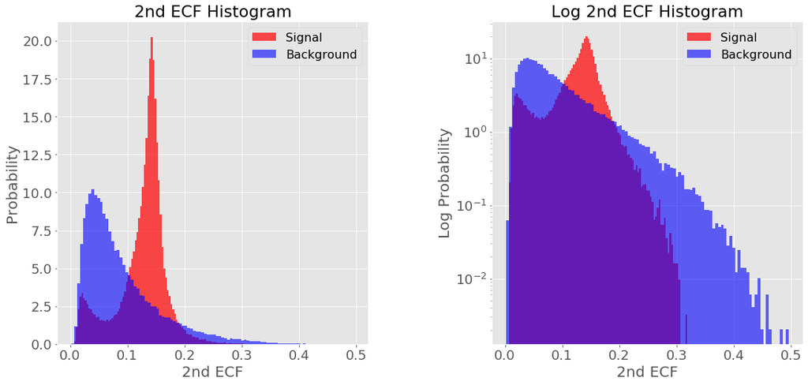

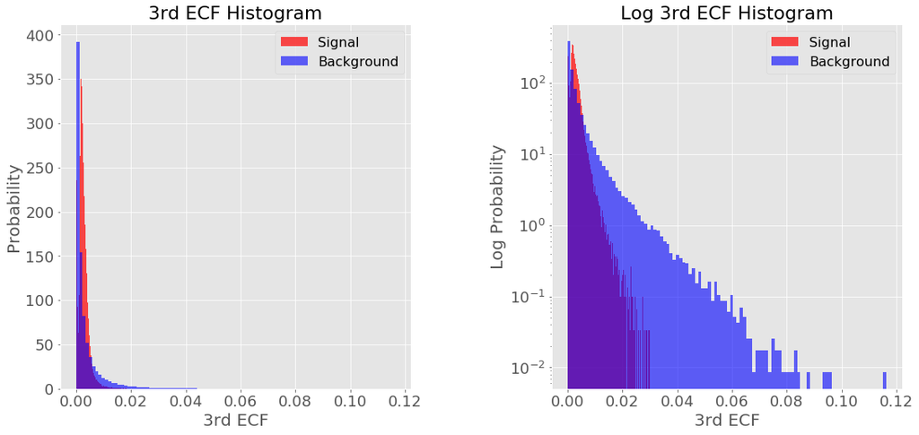

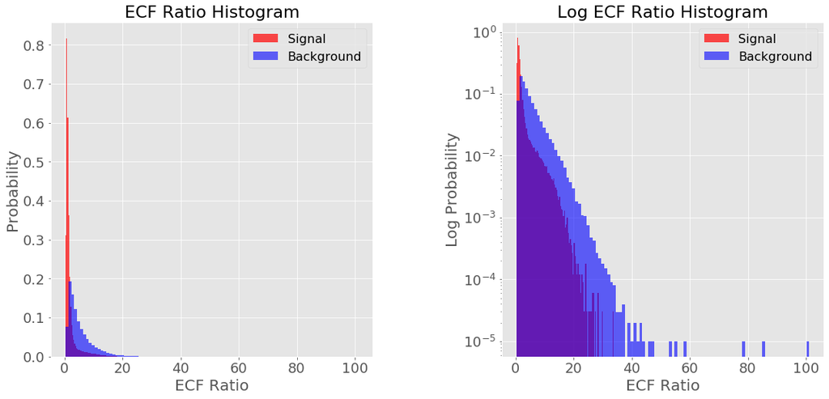

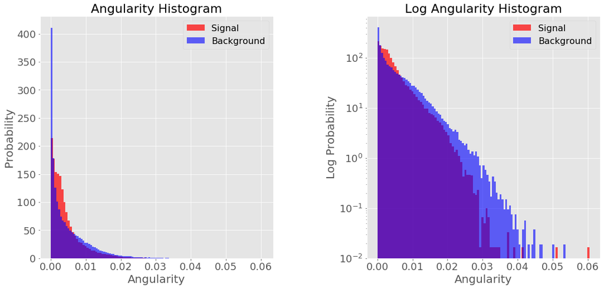

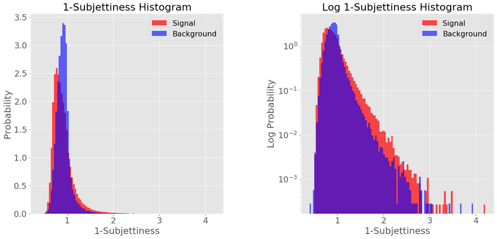

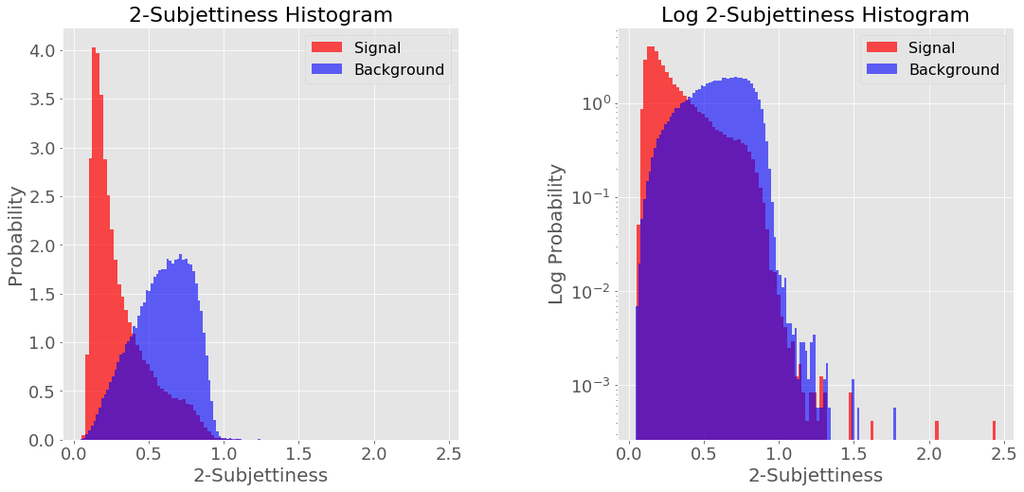

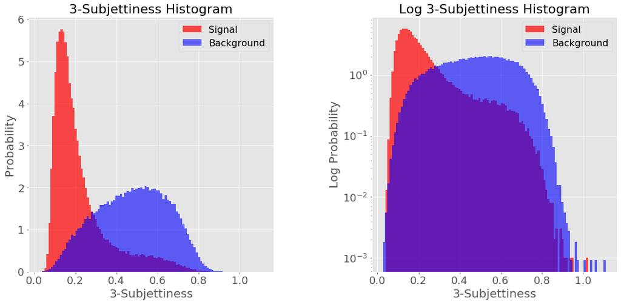

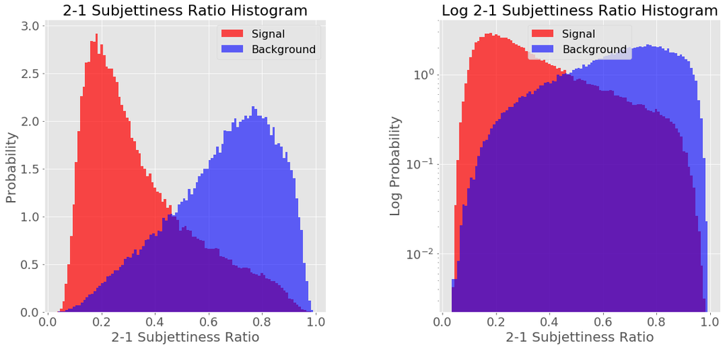

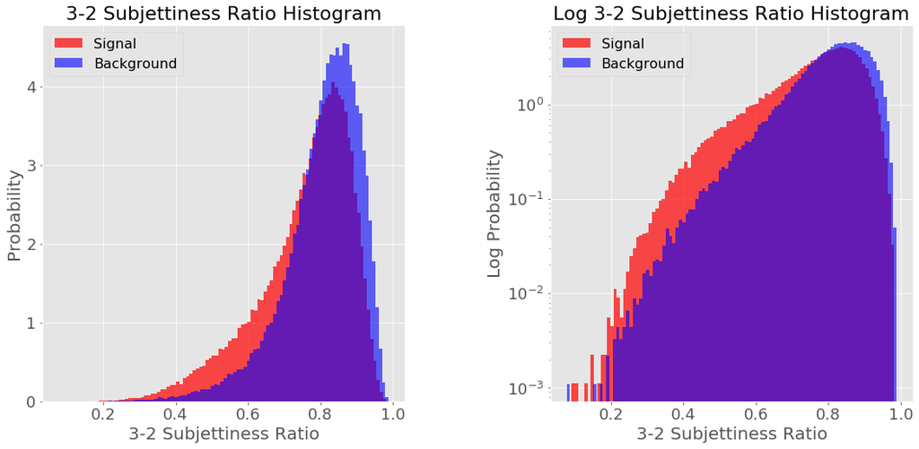

[1 more figures not shown]

```python
keys = ['pt', 'eta', 'phi', 'ee2', 'ee3', 'd2', 'angularity', 't1',
       't2', 't3', 't21', 't32', 'KtDeltaR']
labs = ['Transverse Momentum', '$\eta$', '$\phi$', '2nd ECF', '3rd ECF', 'ECF Ratio',
        'Angularity', '1-Subjettiness', '2-Subjettiness', '3-Subjettiness', '2-1 Subjettiness Ratio',
       '3-2 Subjettiness Ratio','$\Delta$ Angular Distance']

for i in range(len(keys)):
    hist_plotter(higgs_dict[keys[i]],qcd_dict[keys[i]],labs[i])
```

We know that based on our initial histograms, signal mass data was distinctive from background mass data. For parameters where the expected signal and expected background majorly overlap, it is not as easy, or possible at all, to distinguish the signal from the background. For this reason, we can assume the parameters $\phi$, the 3rd ECF, angularity, 1-Subjettiness, and 3-2 Subjettiness ratio are not necessary to final optimal cuts. Attempting to optimize these datasets will likely not improve any statistical significances.

Therefore, I will make optimization cuts on the remaining parameters: transverse momentum, $\eta$, the second ECF, the ECF ratio, 2-Subjettiness, 3-Subjettiness, 2-1 Subjettiness ratio, and $k_t \Delta R$.

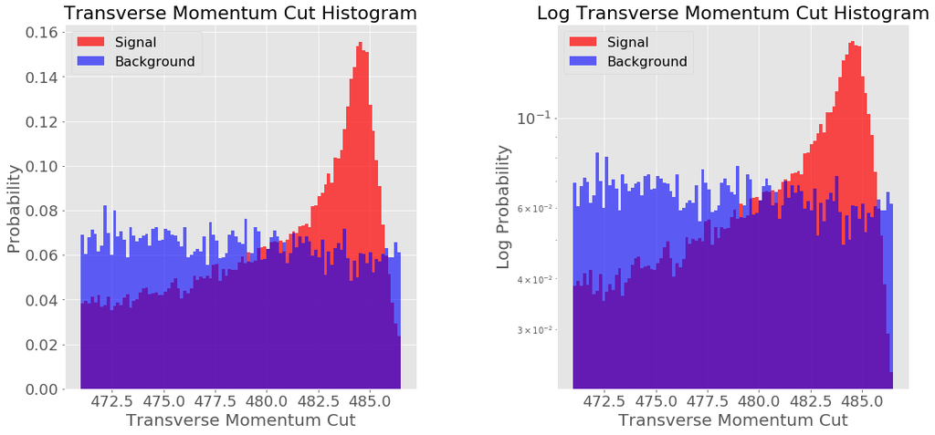

```
Expected Sigma : 0.7876
```

```python
pt = data_slicer('pt',471,486.5,False)
hist_plotter(pt[0],pt[1],'Transverse Momentum Cut')
sigma(pt,'pt')
```

Optimizing the transverse momentum parameter does not yield any statistically significant results. Regardless of how much more I tweak around this range of data values, I can never achieve a $\sigma$ higher than 1.

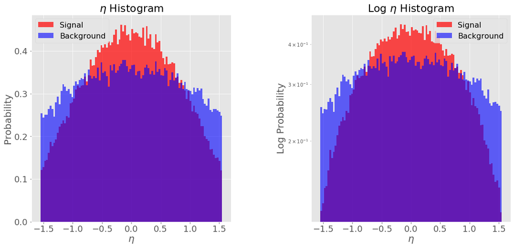

```
Expected Sigma : 3.6925
```

```python
eta = data_slicer('eta',-1.55,1.55,False)
hist_plotter(eta[0],eta[1],'$\eta$')
sigma(eta,'eta')
```

The most optimized cut for the $\eta$ parameter increases the sigma value to 3.69, which is considerably more statistically significant than a $\sigma$ of around 1, which we expect before making any data cuts. However, it is still not at the excepted $5\sigma$ significance even after cutting the data.

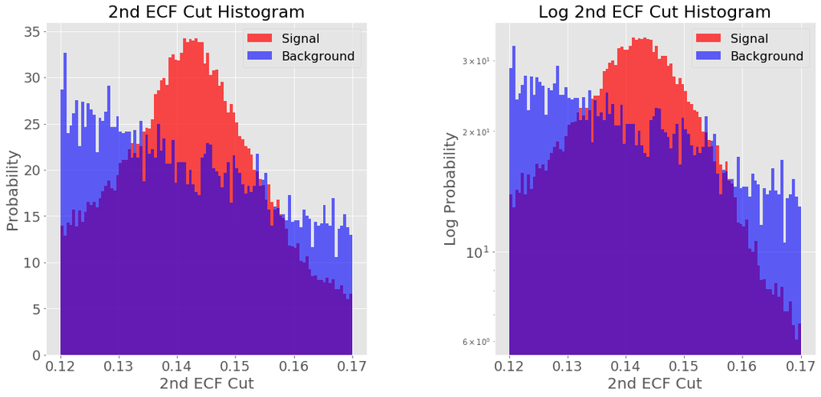

```
Expected Sigma : 1.0760
```

```python
ee2 = data_slicer('ee2',0.12,0.17,False)
hist_plotter(ee2[0],ee2[1],'2nd ECF Cut')
sigma(ee2,'ee2')
```

After cutting the 2nd ECF data, the expected sigma value remains about the same, with no considerable increase in significance.

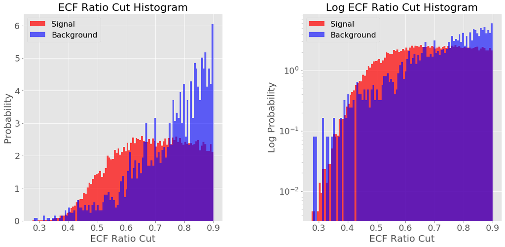

```
Expected Sigma : 1.5848
```

```python
d2 = data_slicer('d2',0.15,0.9,False)
hist_plotter(d2[0],d2[1],'ECF Ratio Cut')
sigma(d2,'d2')
```

The ECF ratio after cuts has a $\sigma$ of about 1.58, slightly improved.

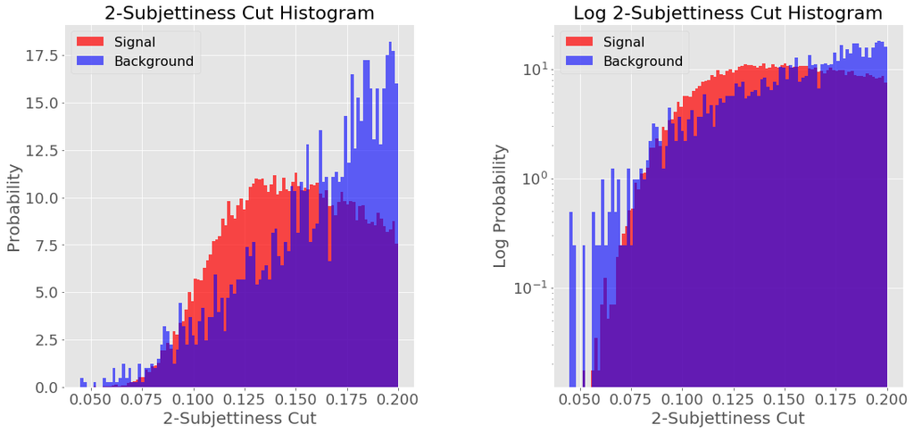

```
Expected Sigma : 1.5415
```

```python
t2 = data_slicer('t2',.009,0.2,False)
hist_plotter(t2[0],t2[1],'2-Subjettiness Cut')
sigma(t2,'t2')
```

The highest we can improve this parameter is to about $\sigma=1.54$, which is only slightly improved after making data cuts.

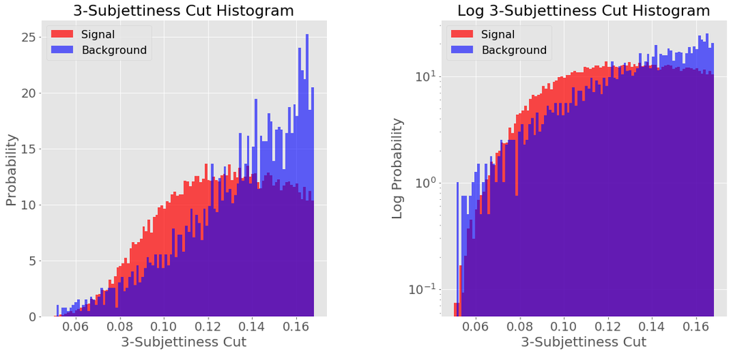

```
Expected Sigma : 1.8282
```

```python
t3 = data_slicer('t3',0.05,0.168,False)
hist_plotter(t3[0],t3[1],'3-Subjettiness Cut')
sigma(t3,'t3')
```

This data cut is similar to the previous, where we have improved the expected significance by about 0.8 this time.

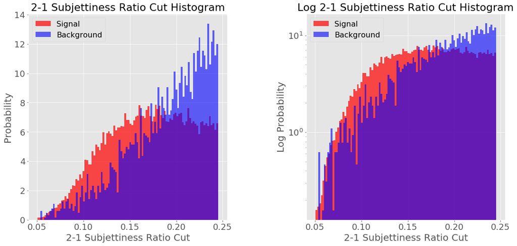

```
Expected Sigma : 1.3675
```

```python
t21 = data_slicer('t21',0.05,0.245,False)
hist_plotter(t21[0],t21[1],'2-1 Subjettiness Ratio Cut')
sigma(t21,'t21')
```

Cutting the 2-1 subjettiness ratio dataset gives at best a $\sigma=1.37$.

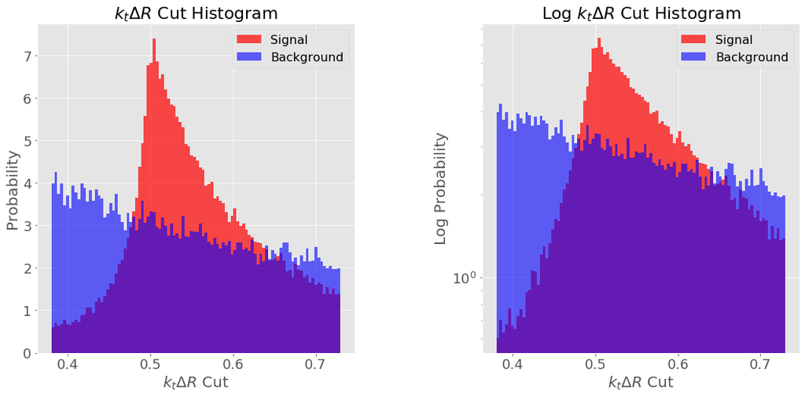

```
Expected Sigma : 0.8136
```

```python
ktdr = data_slicer('KtDeltaR',0.38,0.73,False)
hist_plotter(ktdr[0],ktdr[1],'$k_t \Delta R$ Cut')
sigma(ktdr,'KtDeltaR')
```

The expected sigma value remains low for the '$k_t \Delta R$ parameter even when cut.

```python
# pt before event selection
ptbefore = data_slicer('pt',250,500,False)  # grab all values
print("Transverse momentum before data cuts: ")
sigma(ptbefore,'pt')
print("Transverse momentum after data cuts : ")
sigma(pt,'pt')
```

```
Transverse momentum before data cuts:
Expected Sigma : 0.7071
Transverse momentum after data cuts :
Expected Sigma : 0.7876
```

For the transverse momentum parameter, expected significance is low both before and after data cuts. Data cuts improve the sigma value ever so slightly, by about 0.08. Overall, we don't expect to see significant events in this data.

Compared to my lab partner, this is different from his findings. Arden, who used the high momentum sample (transverse momentum values ranged from 1000 to 1200; expected NHiggs = 50; expected NQCD = 2000), found much higher statistical significances for most of his parameters: Mass with $\sigma=5.2$ (significant), 2nd ECF with $\sigma=2.3$, 3rd ECF with $\sigma=4.95$, 3-2 ECF ratio with $\sigma=2.5$, angularity with $\sigma=2.14$, 2-Subjettiness with $\sigma=1.85$, 3-subjettiness with $\sigma=2.1$, 2-1 Subjettiness with $\sigma=1.85$, and KtDeltaR with $\sigma=2.25$.

Overall, my thoughts are that we would expect more statistically significant observations with the high momentum data samples. It may be that the low pt sample is less exciting from a particle physics point of view, and that most events will be due to the background, while in the high pt sample this may not be exactly the same case.

# Part 2: Signal Hunting Using Data Cuts

Next, we can apply our optimized data cuts for the expected background and signal to a set of observed data. We then can analyze the statistical significance for observed data inside the cut to see if there are any potential Higgs events. The following plots will show the expected signal and background in each cut determined previously, with the observed data set overlayed.

```python
# another histogram plotter which shows before and after cuts of all three datasets at once, plus logs of each.
# there is definitely a nicer way to write this function. . .
def four_hist(param,obs,cut,lumlvl):
    bins = 100

    plt.style.use('ggplot')
    fig, ((ax1, ax2), (ax3, ax4)) = plt.subplots(2,2, figsize=(22,16), gridspec_kw={'wspace': 0.3})

    fig.subplots_adjust(hspace=0.4, wspace=0.4)
    fig.suptitle(param+" histogram, before and after datacuts",fontsize=26)
    ax1.set_xlabel(param, fontsize=20), ax2.set_xlabel(param, fontsize=20)
    ax3.set_xlabel(param, fontsize=20), ax4.set_xlabel(param, fontsize=20)
    ax1.set_ylabel("Probability", fontsize=20), ax2.set_ylabel("Log Probability", fontsize=20)
    ax3.set_ylabel("Probability", fontsize=20), ax4.set_ylabel("Log Probability", fontsize=20)
    ax1.tick_params(labelsize=18), ax2.tick_params(labelsize=18), ax3.tick_params(labelsize=18)
    ax4.tick_params(labelsize=18)

    ax1.hist(higgs_dict[param],bins=bins,density=True,color='r',alpha=0.7,label="Expected Signal")
    ax1.hist(qcd_dict[param],bins=bins,density=True,color='b',alpha=0.6,label="Expected Background")
    ax1.hist(obs,bins=bins,density=True,color='mediumaquamarine',alpha=0.6,label="Observed")

    ax2.set_yscale('log')
    ax2.hist(higgs_dict[param],bins=bins,density=True,color='r',alpha=0.7)
    ax2.hist(qcd_dict[param],bins=bins,density=True,color='b',alpha=0.6)
    ax2.hist(obs,bins=bins,density=True,color='mediumaquamarine',alpha=0.6)

    ax3.hist(cut[0],bins=bins,density=True,color='r',alpha=0.7)
    ax3.hist(cut[1],bins=bins,density=True,color='b',alpha=0.6)

    ax4.set_yscale('log')
    ax4.hist(cut[0],bins=bins,density=True,color='r',alpha=0.7)
    ax4.hist(cut[1],bins=bins,density=True,color='b',alpha=0.6)

    if lumlvl == "high":
        ax3.hist(cut[2],bins=bins,density=True,color='mediumaquamarine',alpha=0.6)
        ax4.hist(cut[2],bins=bins,density=True,color='mediumaquamarine',alpha=0.6)
    else:
        ax3.hist(cut[3],bins=bins,density=True,color='mediumaquamarine',alpha=0.6)
        ax4.hist(cut[3],bins=bins,density=True,color='mediumaquamarine',alpha=0.6)

    fig.legend(loc='upper left',fontsize=24)
    plt.show()
```

```python
# a function to calculate observed sigma values, since the previous function only works for the higgs/qcd sample sets.
# definitely could improve this redundancy later on.
def obs_sigma(cut,obs,param,lumlvl):
    # first normalize
    n, nqcd, l = 100, 20000, 0
    if lumlvl is highlum:
        l = 2
    else: l = 3  # chose between the high and low datasets
    norm = (sum(cut[0]) / sum(higgs_dict[param])) * n
    normbg = (sum(obs[l]) / sum(lumlvl[param])) * nqcd

    r = np.abs(norm / np.sqrt(normbg))  # ratio
    print("Observed Sigma : " + str("{0:.4f}".format(r)))
```

## High Luminosity Data

First, we will look at the high luminosity pseudo-experimental data for all parameters. To do this, we have to apply the optimal mass cuts (found in the previous part of the lab by maximizing the sigma values), then plot using the function written above. Each figure contains four plots: (top row) the standard uncut signal, background, and observational data; the log of the uncut data; (bottom row) the optimally cut signal, background, and observed data; the log of the cut data. The statistical significances for the optimized/cut data are printed below the figure for each parameter.

Note: we only need to look at the parameters we made optimization cuts for previously. Since it is difficult to distinguish the difference between the background and signal in some parameters ($\phi$, the 3rd ECF, angularity, 1-Subjettiness, and 3-2 Subjettiness ratio), we will only look at transverse momentum, $\eta$, the second ECF, the ECF ratio, 2-Subjettiness, 3-Subjettiness, 2-1 Subjettiness ratio, and $k_t \Delta R$ using the high and low luminosity pseudo data.

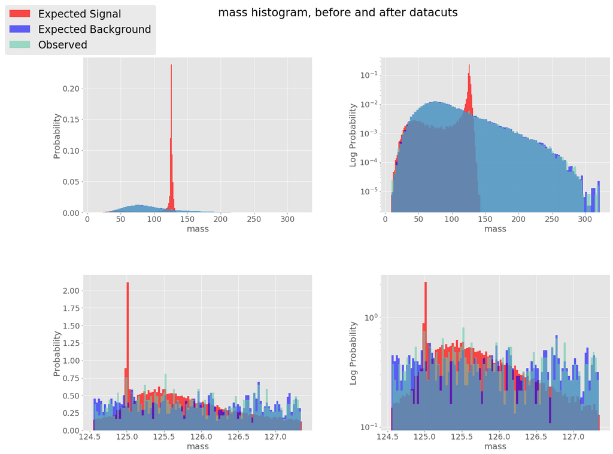

```
Expected Sigma : 3.0868
Observed Sigma : 2.7932
```

```python
massObs = data_slicer('mass',124.55,127.35,True)
four_hist('mass',highlum['mass'],massObs,"high")
sigma(c3,'mass')
obs_sigma(c3,massObs,'mass',highlum)
```

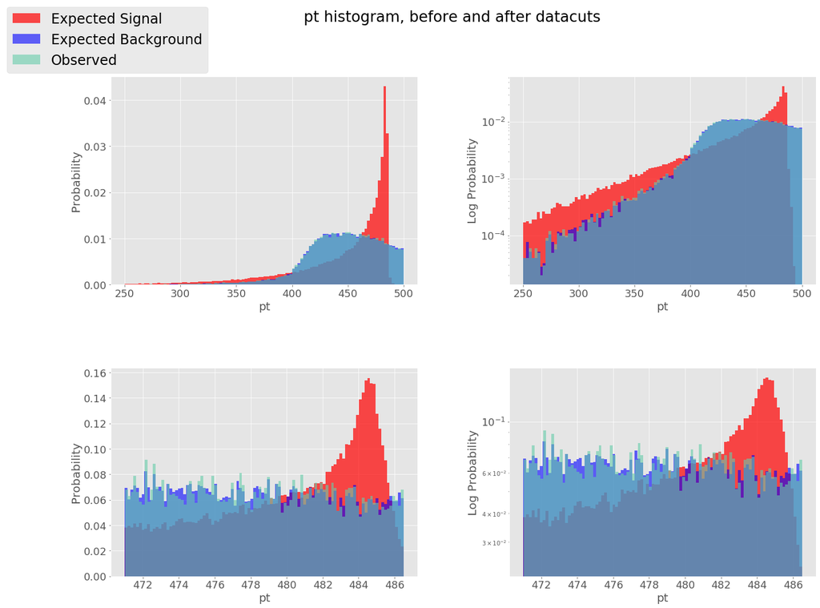

```
Expected Sigma : 0.7876
Observed Sigma : 0.7803
```

```python
ptObs = data_slicer('pt',471,486.5,True)
four_hist('pt',highlum['pt'],ptObs,"high")
sigma(pt,'pt')
obs_sigma(pt,ptObs,'pt',highlum)
```

Between the expected and observed datasets, the sigma values do not change for the transverse momentum parameter. Again, the observed data follows the regular background noise pretty closely, as seen in the overlaps in the pt figure. We generally wouldn't expect to see a discovery in data that is essentially just following the background noise.

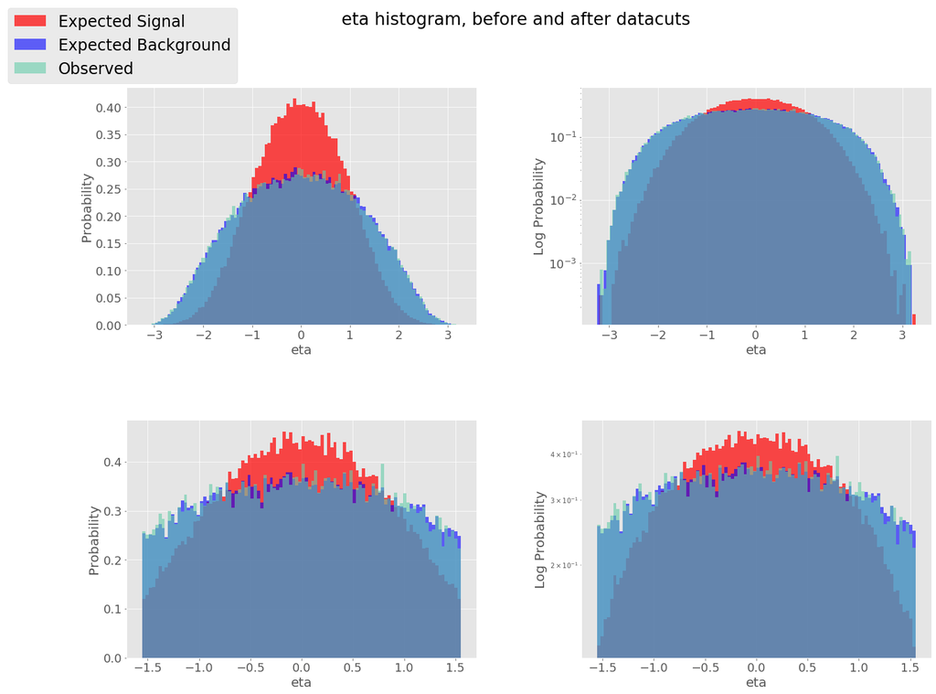

```
Expected Sigma : 3.6925
Observed Sigma : 2.2083
```

```python
etaObs = data_slicer('eta',-1.55,1.55,True)
four_hist('eta',highlum['eta'],etaObs,"high")
sigma(eta,'eta')
obs_sigma(eta,etaObs,'eta',highlum)
```

The $\eta$ sigma value drops significantly after introducing the observed dataset. This is not a statistically significant observation. Overall, the background and observed data once again closely match.

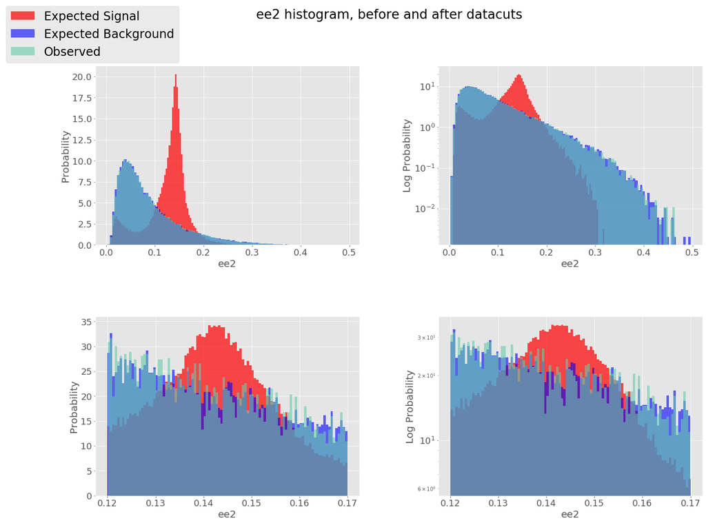

```
Expected Sigma : 1.0760
Observed Sigma : 1.0683
```

```python
ee2Obs = data_slicer('ee2',0.12,0.17,True)
four_hist('ee2',highlum['ee2'],ee2Obs,"high")
sigma(ee2,'ee2')
obs_sigma(ee2,ee2Obs,'ee2',highlum)
```

This is similar to the previous result, where the sigma value for the 2nd ECF did not noticeably change. In the graphs, there are a few noticeable differences (dips) between the background and observed data. However, these are not statistically significant findings.